[figure not shown]

# Explanatory Data Analysis - Deriv CRP

# I. Trading clients analysis

```python
import pandas as pd
import numpy as np
import matplotlib.pyplot as plt
import seaborn as sns
```

```python
!gdown '12w5dO9DHPKx-nw0f-tV8HL4fgZt_SMrK'
df_trades = pd.read_csv('Trading Clients.csv')
```

```
Downloading...
From: https://drive.google.com/uc?id=12w5dO9DHPKx-nw0f-tV8HL4fgZt_SMrK
To: /content/Trading Clients.csv
100% 318M/318M [00:01<00:00, 280MB/s]
```

- **Exploring the profit columns**

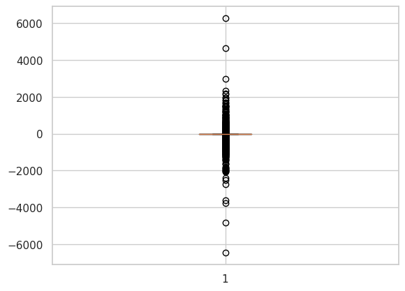

```python
plt.boxplot(df_trades['profit'])
plt.show()
```

From the boxplot, we can immediately see that the data has a high variance, as the boxplot is not clearly visible. This indicates that the majority of the values are clustered around zero, or even zero. To gain a better understanding of the data, let's plot a histogram summarizing its distribution.

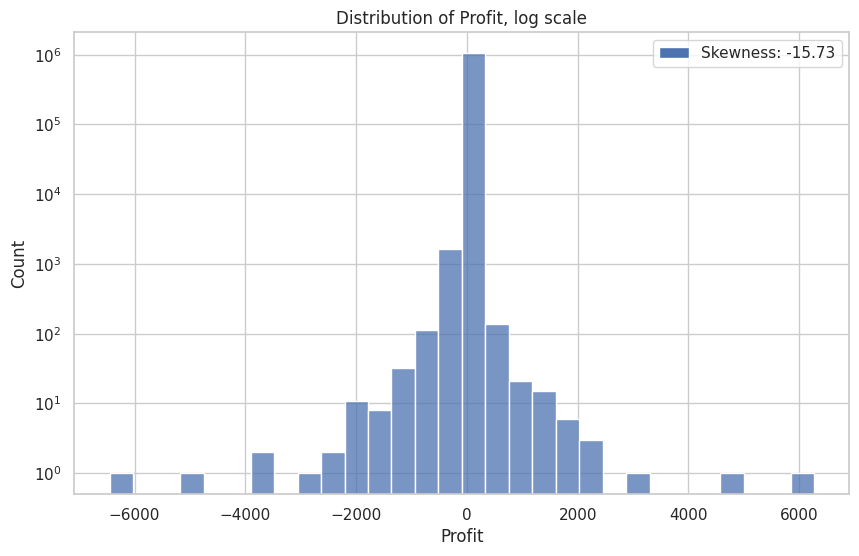

```python
import scipy.stats as stats

# Figure size
plt.figure(figsize = (10,6))

# Create a histogram of the 'num_trades' data
sns.histplot(data=df_trades['profit'], bins=30)

# Set plot title and axis labels
plt.title('Distribution of Profit, log scale')
plt.xlabel('Profit')
plt.ylabel('Count')

# Use a logarithmic scale for the y-axis
plt.yscale('log')

# Calculate skewness of the data
skewness = stats.skew(df_trades['profit'])
# Add skewness to the plot as a legend
plt.legend([f"Skewness: {skewness:.2f}"])

# Show the plot
plt.show()
```

- **Percentages of people by profit.**

```python
num_zero_profit = len(df_trades[df_trades['profit'] == 0])
num_pos_profit=len(df_trades[df_trades['profit'] > 0])
num_neg_profit=len(df_trades[df_trades['profit'] < 0])
n=len(df_trades['profit'])
p=num_zero_profit/n *100

print("Percentage of people with zero profit: ", round(p,2), "%")
print("Percentage of people with positive profit: ", round(num_pos_profit/n * 100,2), "%")
print("Percentage of people with negative profit: ", round(num_neg_profit/n * 100,2), "%")
```

```
Percentage of people with zero profit:  48.01 %
Percentage of people with positive profit:  30.09 %
Percentage of people with negative profit:  21.9 %
```

We can see that a greater proportion of individuals have generated positive profits in comparison to those who have incurred losses.

About half of the trades result in neither profit nor loss, which is due to the nature of CFDs.

- **Platform used**

```python
len(df_trades[df_trades['cfd_platform'] == 'MT5'])/len(df_trades) *100
```

```
100.0
```

All of the trades were conducted throughout the MT5 platform

- **Number of trades per client**

```python
deals_per_login = df_trades.groupby('login').count()['deal']
deals_per_login = deals_per_login.sort_values(ascending=False)
```

Let's take a look at the Logins with the highest number of trades

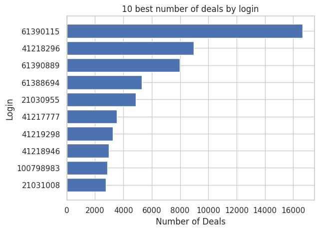

```python
x = deals_per_login.values[:10][::-1]
y = [str(v) for v in deals_per_login.index[:10:]][::-1]

# Create horizontal bar graph
plt.barh(y, x)

# Add labels and title
plt.xlabel('Number of Deals')
plt.ylabel('Login')
plt.title('10 best number of deals by login')

# Show the plot
plt.show()
```

```python
deals_per_login.describe()
```

```
count    13621.000000
mean        76.982233
std        248.860849
min          1.000000
25%          7.000000
50%         22.000000
75%         71.000000
max      16665.000000
Name: deal, dtype: float64
```

The dataset consists of 13,621 distinct logins, with a mean of 76.98 deals per login and a standard deviation of 248.86. The minimum number of deals for a login is 1, while the maximum number is 16,665.

The median number of deals per login is 22, and 75% of logins have 71 or fewer deals. This suggests that the majority of logins have a relatively moderate number of deals, with a small number of logins having a very high number of deals.

- **Analysis of means for deal placement**

```python
df_trades['reason'].value_counts()
```

```
16    689456
0     154316
1      71506
3      39266
5      38146
17     28758
4      27127
Name: reason, dtype: int64
```

```python
print("Percentage of deals that were placed using MT5 mobile terminal for android or Iphone: ", round(len(df_trades[df_trades['reason']==16])/len(df_trades['reason']) * 100,2),'%')
print("Percentage of deals that were placed the order manually through the client terminal: ", round(len(df_trades[df_trades['reason']==0])/len(df_trades['reason']) * 100,2),'%')
print("Percentage of deals that were placed using an expert adviser: ", round(len(df_trades[df_trades['reason']==1])/len(df_trades['reason']) * 100,2),'%')
print("Percentage of deals that were placed as a result of stop loss activitation: ", round(len(df_trades[df_trades['reason']==3])/len(df_trades['reason']) * 100,2),'%')
print("Percentage of deals that were placed as a when the client reached stop-out level: ", round(len(df_trades[df_trades['reason']==5])/len(df_trades['reason']) * 100,2),'%')
print("Percentage of deals that were placed via web terminal: ", round(len(df_trades[df_trades['reason']==17])/len(df_trades['reason']) * 100,2),'%')
print("Percentage of deals that were placed as a result of take profit activitation: ", round(len(df_trades[df_trades['reason']==4])/len(df_trades['reason']) * 100,2),'%')
```

```
Percentage of deals that were placed using MT5 mobile terminal for android or Iphone:  65.75 %
Percentage of deals that were placed the order manually through the client terminal:  14.72 %
Percentage of deals that were placed using an expert adviser:  6.82 %
Percentage of deals that were placed as a result of stop loss activitation:  3.74 %
Percentage of deals that were placed as a when the client reached stop-out level:  3.64 %
Percentage of deals that were placed via web terminal:  2.74 %
Percentage of deals that were placed as a result of take profit activitation:  2.59 %
```

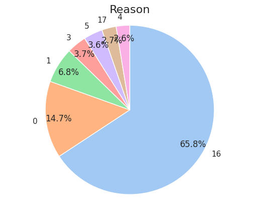

```python
import matplotlib.pyplot as plt
import seaborn as sns

# Get the count of reasons
reason_counts = df_trades['reason'].value_counts()

# Define a color palette
colors = sns.color_palette('pastel')[0:len(reason_counts)]

# Create a pie chart
plt.pie(reason_counts, labels=reason_counts.index, colors=colors, autopct='%1.1f%%', startangle=90, counterclock=False, wedgeprops={'linewidth':1, 'edgecolor':'white'}, pctdistance=0.85)

# Add a title
plt.title('Reason', fontsize=16)

# Remove the y-axis label
plt.ylabel('')

# Set the aspect ratio to 'equal'
plt.axis('equal')

# Show the chart
plt.show()
```

- **Analysis of trade volumes per weekday / throughout the month**

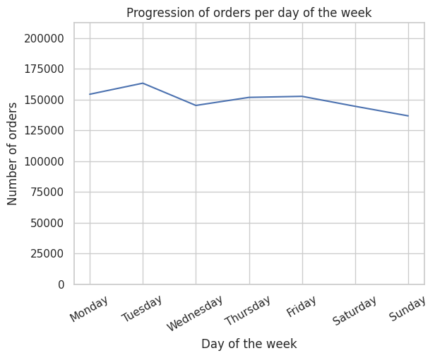

```python
import pandas as pd
import matplotlib.pyplot as plt

# Assuming that df is your pandas DataFrame
df_trades['time_deal'] = pd.to_datetime(df_trades['time_deal'])
df_trades['day_of_week'] = df_trades['time_deal'].dt.dayofweek

# Count the orders per day of the week
orders_per_day = df_trades.groupby('day_of_week').size()

# Create a line plot of the orders per day of the week
labels = ['Monday', 'Tuesday', 'Wednesday', 'Thursday', 'Friday', 'Saturday', 'Sunday']
plt.plot(labels, orders_per_day)
plt.xlabel('Day of the week')
plt.ylabel('Number of orders')
plt.title('Progression of orders per day of the week')

# Rotate the x-axis labels
plt.xticks(rotation=30)

# Set y-axis limit to 0 and maximum value in the data + 10% buffer
plt.ylim(0, orders_per_day.max()*1.3)

# Display the line plot
plt.show()
```

We can observe a slight decrease in the number of trades on Sunday.

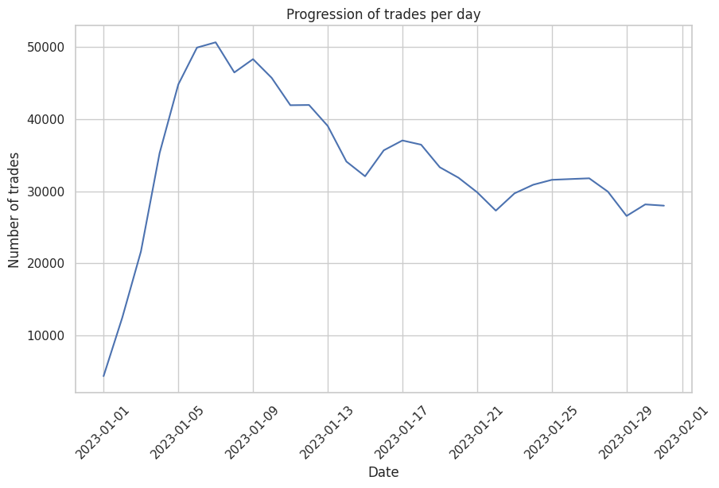

```python
import matplotlib.dates as mdates

# Assuming that df is your pandas DataFrame
df_trades['time_deal'] = pd.to_datetime(df_trades['time_deal'], format='%Y-%m-%d')

# Group the DataFrame by the day of the timestamp and count the number of rows per day
grouped = df_trades.groupby(df_trades['time_deal'].dt.date).size()

# Create a line plot of the number of rows per day
fig, ax = plt.subplots(figsize=(10, 6))
ax.plot(grouped.index, grouped.values)

# Format the x-axis labels as dates
date_fmt = mdates.DateFormatter('%Y-%m-%d')
ax.xaxis.set_major_formatter(date_fmt)
ax.xaxis.set_tick_params(rotation=45)

# Add axis labels and title
ax.set_xlabel('Date')
ax.set_ylabel('Number of trades')
ax.set_title('Progression of trades per day')

# Display the line plot
plt.show()
```

Interestingly enough, there was a steep increase in the number of trades in the beginning of the year, followed by a subsequent decrease until the end of the month. In addition to the subsequent decrease, there were peaks of data, possibly indicating weekly seasonality.

# II. Deposit client analysis

```python
!gdown '1g61wbb7Ya8-oscUd40tAqgKKWrolgpmZ'

df2=pd.read_csv('Deposit client.csv')
```

```python
print(df2.isnull().sum())
```

```
time_deal      0
login          0
deposit_usd    0
dtype: int64
```

No null values in our dataset

- **Logins per day**

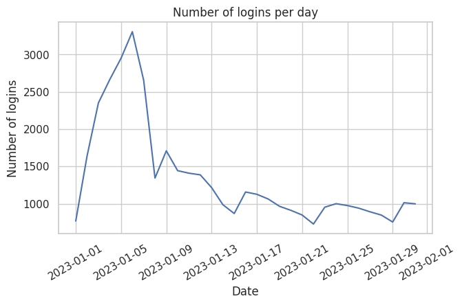

```python
import matplotlib.pyplot as plt

# convert 'time_deal' column to datetime format
df2['time_deal'] = pd.to_datetime(df2['time_deal'])

# extract date from time_deal column
df2['date'] = df2['time_deal'].dt.date

# groupby date and count the number of unique logins
login_counts = df2.groupby('date')['login'].nunique()

# plot the data
login_counts.plot(kind='line', figsize=(7, 4))
plt.xlabel('Date')
plt.ylabel('Number of logins')

# Rotate the x-axis labels
plt.xticks(rotation=30)

plt.title('Number of logins per day')
plt.show()
```

As with the 'Progression of trades per day' graph, we can see a sudden peak at the beginning of the graph, followed by a rapid decrease. Similar to the previous graph, there are also data peaks that reinforce the existence of weekly seasonality.

- **Deposits per day**

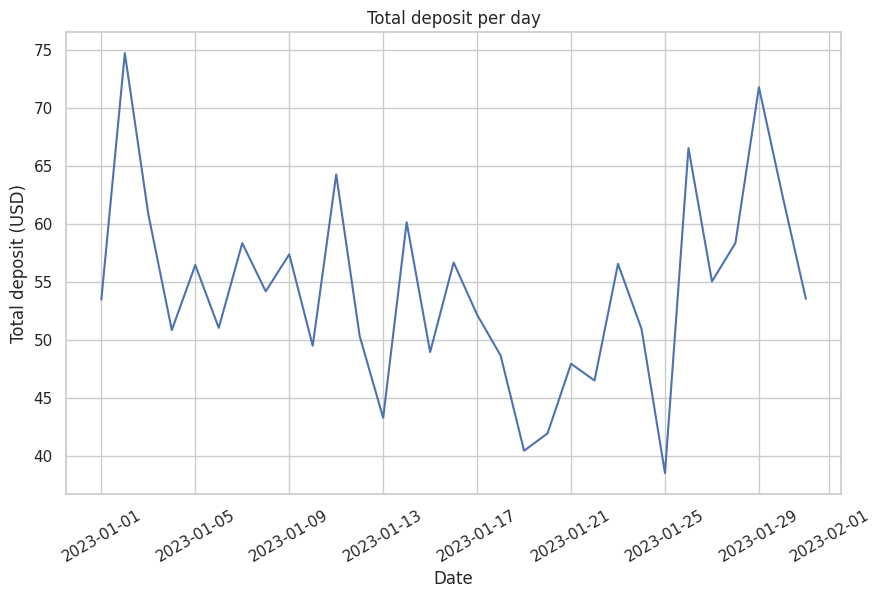

```python
# extract date from time_deal column
df2['date'] = df2['time_deal'].dt.date

# groupby date and sum the deposit_usd column
deposit_totals = df2.groupby('date')['deposit_usd'].mean()

# plot the data
deposit_totals.plot(kind='line', figsize=(10, 6))
plt.xlabel('Date')
plt.ylabel('Total deposit (USD)')

# Rotate the x-axis labels
plt.xticks(rotation=30)

plt.title('Total deposit per day')
plt.show()
```

```python
avg_deposit = df2.groupby('login')['deposit_usd'].mean()
avg_deposit.describe()
```

```
count    15861.000000
mean        64.945902
std        305.157963
min          0.010000
25%          7.036667
50%         14.175000
75%         40.500000
max      13295.710000
Name: deposit_usd, dtype: float64
```

The dataset contains 15861 unique users with an average deposit of 64.95 USD. The standard deviation of the deposit is relatively high at 305.16 USD, indicating a wide range of deposit values. The minimum deposit made by a user is 0.01 USD, while the maximum deposit is 13295.71 USD. The interquartile range (IQR), which represents the middle 50% of the data, is between 7.04 USD and 40.50 USD.

- **Define our top clients, mid clients and small clients and group each of them in a variable**

This code is used to categorize clients into three categories based on the number of trades they have made:

1. Top Clients: clients who have made more than 100 trades.
2. Mid Clients: clients who have made between 6 and 99 trades.
3. Small Clients: clients who have made 5 trades or less.

```python
# Group the data by unique clients and count the number of trades made by each client
trades_per_client = df_trades.groupby('login').size().reset_index(name='num_trades')

# Sort the clients in descending order based on the number of trades
sorted_clients = trades_per_client.sort_values('num_trades', ascending=False)

# Calculate the number of clients that make up the top clients
top_clients_count = (trades_per_client['num_trades'] > 100).sum()

# Select the top clients based on the number of trades
top_clients = sorted_clients[sorted_clients['num_trades'] > 100].head(top_clients_count)

# Select the clients that have between 6 and 99 trades
mid_clients = trades_per_client[(trades_per_client['num_trades'] > 5) & (trades_per_client['num_trades'] <= 99)]

# Select the clients with 5 trades or less
small_clients= trades_per_client[(trades_per_client['num_trades'] <= 5)]
```

- Proportion of clients per type

```python
# Calculate the proportion and percentage of top clients
top_clients_prop = len(top_clients) / len(trades_per_client)
top_clients_pct = top_clients_prop * 100

# Calculate the proportion and percentage of mid clients
mid_clients_prop = len(mid_clients) / len(trades_per_client)
mid_clients_pct = mid_clients_prop * 100

# Calculate the proportion and percentage of small clients
small_clients_prop = len(small_clients) / len(trades_per_client)
small_clients_pct = small_clients_prop * 100

# Print the results
print(f'Top clients: {top_clients_prop:.2%} ')
print(f'Mid clients: {mid_clients_prop:.2%} ')
print(f'Small clients: {small_clients_prop:.2%} ')
```

```
Top clients: 18.38%
Mid clients: 60.14%
Small clients: 21.24%
```

We can see that by far our most common type of client is the Mid clients, composing 60.14% of our costumers.

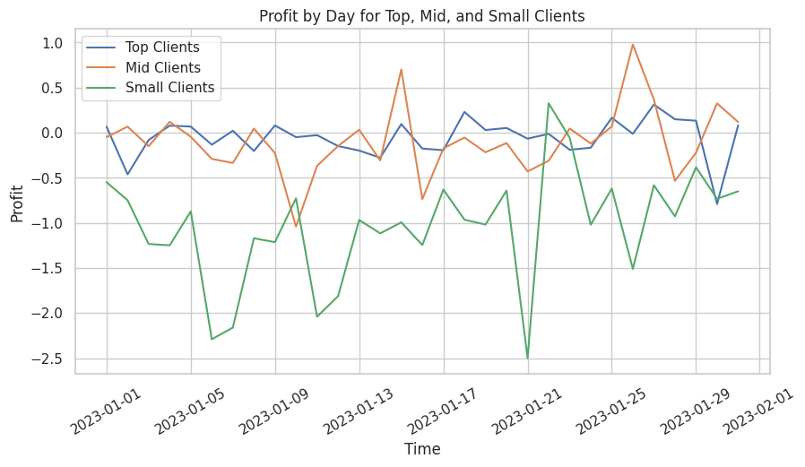

```python
# Group the data by unique clients and count the number of trades made by each client
trades_per_client = df_trades.groupby('login').size().reset_index(name='num_trades')

# Sort the clients in descending order based on the number of trades
sorted_clients = trades_per_client.sort_values('num_trades', ascending=False)

top_clients_trades = df_trades[df_trades['login'].isin(top_clients['login'])].copy()
mid_clients_trades = df_trades[df_trades['login'].isin(mid_clients['login'])].copy()
small_clients_trades = df_trades[df_trades['login'].isin(small_clients['login'])].copy()


# Convert the 'time_deal' column to a datetime object
top_clients_trades.loc[:, 'time_deal'] = pd.to_datetime(top_clients_trades['time_deal'])
mid_clients_trades.loc[:, 'time_deal'] = pd.to_datetime(mid_clients_trades['time_deal'])
small_clients_trades.loc[:, 'time_deal'] = pd.to_datetime(small_clients_trades['time_deal'])


# Group the data by day and sum the 'profit_usd' column for each client category
deposits_by_day_top = top_clients_trades.groupby(pd.Grouper(key='time_deal', freq='D'))['profit_usd'].mean()
deposits_by_day_mid = mid_clients_trades.groupby(pd.Grouper(key='time_deal', freq='D'))['profit_usd'].mean()
deposits_by_day_small = small_clients_trades.groupby(pd.Grouper(key='time_deal', freq='D'))['profit_usd'].mean()

# Plot the profit information against the time period for each client category
fig, ax = plt.subplots(figsize=(10, 5))

ax.plot(deposits_by_day_top.index, deposits_by_day_top.values, label='Top Clients')
ax.plot(deposits_by_day_mid.index, deposits_by_day_mid.values, label='Mid Clients')
ax.plot(deposits_by_day_small.index, deposits_by_day_small.values, label='Small Clients')

# Rotate the x-axis labels
plt.xticks(rotation=30)

ax.set_xlabel('Time')
ax.set_ylabel('Profit')
ax.set_title('Profit by Day for Top, Mid, and Small Clients')
ax.legend()
plt.show()
```

## Merge the two datasets

In this section of the notebook, we shall combine both datasets we've worked on so far, find interesting correlations, and draw insights from the data.

```python
# Load the dataset with deposit information into a pandas DataFrame
df_deposits = df2

# Convert the 'time_deal' column to a datetime object in both datasets
df_trades.loc[:, 'time_deal'] = pd.to_datetime(df_trades['time_deal'])
df_deposits.loc[:, 'time_deal'] = pd.to_datetime(df_deposits['time_deal'])

# Merge the trade and deposit datasets
merged_df = pd.merge(df_trades, df_deposits, on=['login', 'time_deal'], how='outer')

# Fill missing values with 0
merged_df.fillna(0, inplace=True)

# Group the data by unique clients and count the number of trades made by each client
trades_per_client = merged_df.groupby('login').size().reset_index(name='num_trades')

# Sort the clients in descending order based on the number of trades
sorted_clients = trades_per_client.sort_values('num_trades', ascending=False)
```

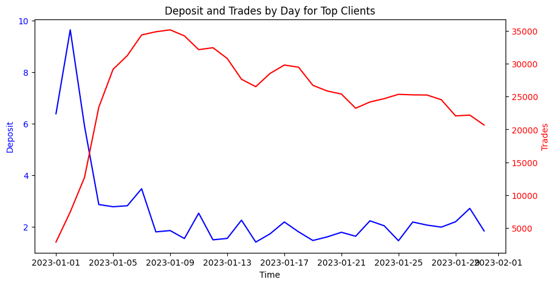

```python
# Filter the dataset to include only the trades made by top_clients
top_clients_trades = merged_df[merged_df['login'].isin(top_clients['login'])]

# Group the data by day and sum the 'deposit_usd' column for the top clients
deposits_by_day = top_clients_trades.groupby(pd.Grouper(key='time_deal', freq='D'))['deposit_usd'].mean()

# Group the data by day and count the number of trades made by the top clients
trades_by_day = top_clients_trades.groupby(pd.Grouper(key='time_deal', freq='D'))['login'].count()

# Plot the deposit and trade information against the time period for the top clients
fig, ax1 = plt.subplots(figsize=(10, 5))

ax1.plot(deposits_by_day.index, deposits_by_day.values, color='blue')
ax1.set_xlabel('Time')
ax1.set_ylabel('Deposit', color='blue')
ax1.tick_params(axis='y', labelcolor='blue')

ax2 = ax1.twinx()

ax2.plot(trades_by_day.index, trades_by_day.values, color='red')
ax2.set_ylabel('Trades', color='red')
ax2.tick_params(axis='y', labelcolor='red')

plt.title('Deposit and Trades by Day for Top Clients')
plt.show()
```

Similar to the previous graphs, we observed a sharp rise in both trades and deposits at the beginning of the year. However, the number of deposits experienced a significant decline while the trades gradually decreased throughout the rest of the month.

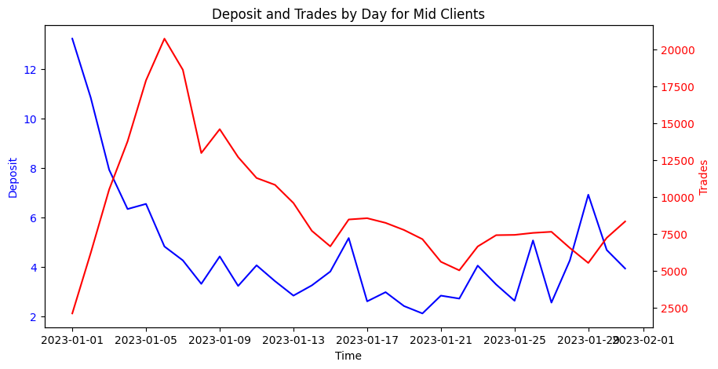

```python
# Filter the dataset to include only the trades made by mid_clients
mid_clients_trades = merged_df[merged_df['login'].isin(mid_clients['login'])]

# Group the data by week and sum the 'deposit_usd' column for the mid clients
deposits_by_day = mid_clients_trades.groupby(pd.Grouper(key='time_deal', freq='D'))['deposit_usd'].mean()

# Group the data by week and count the number of trades made by the mid clients
trades_by_day = mid_clients_trades.groupby(pd.Grouper(key='time_deal', freq='D'))['login'].count()

# Plot the deposit and trade information against the time period for the mid clients
fig, ax1 = plt.subplots(figsize=(10, 5))

ax1.plot(deposits_by_day.index, deposits_by_day.values, color='blue')
ax1.set_xlabel('Time')
ax1.set_ylabel('Deposit', color='blue')
ax1.tick_params(axis='y', labelcolor='blue')

ax2 = ax1.twinx()

ax2.plot(trades_by_day.index, trades_by_day.values, color='red')
ax2.set_ylabel('Trades', color='red')
ax2.tick_params(axis='y', labelcolor='red')

plt.title('Deposit and Trades by Day for Mid Clients')
plt.show()
```

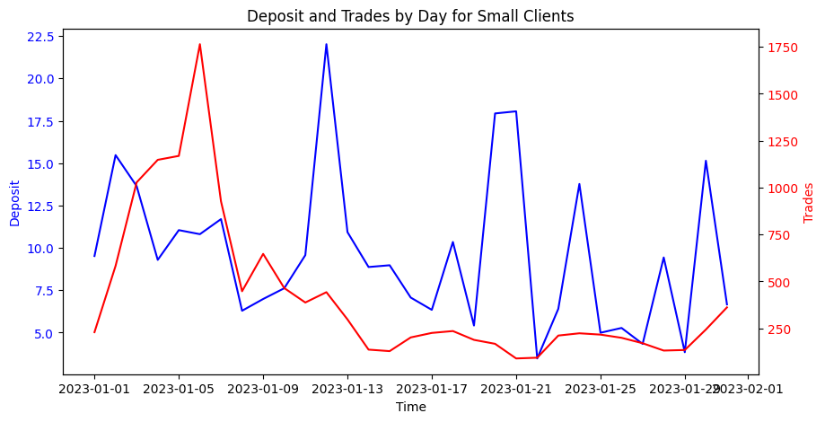

```python
# Filter the dataset to include only the trades made by small_clients
small_clients_trades = merged_df[merged_df['login'].isin(small_clients['login'])]

# Group the data by week and sum the 'deposit_usd' column for the small clients
deposits_by_day = small_clients_trades.groupby(pd.Grouper(key='time_deal', freq='D'))['deposit_usd'].mean()

# Group the data by week and count the number of trades made by the small clients
trades_by_day = small_clients_trades.groupby(pd.Grouper(key='time_deal', freq='D'))['login'].count()

# Plot the deposit and trade information against the time period for the small clients
fig, ax1 = plt.subplots(figsize=(10, 5))

ax1.plot(deposits_by_day.index, deposits_by_day.values, color='blue')
ax1.set_xlabel('Time')
ax1.set_ylabel('Deposit', color='blue')
ax1.tick_params(axis='y', labelcolor='blue')

ax2 = ax1.twinx()

ax2.plot(trades_by_day.index, trades_by_day.values, color='red')
ax2.set_ylabel('Trades', color='red')
ax2.tick_params(axis='y', labelcolor='red')

plt.title('Deposit and Trades by Day for Small Clients')
plt.show()
```

## Correlation

In this section, we will investigate the relationship between a client's initial deposit and their categorization as a small, mid, or top client. By analyzing the data, we aim to determine if there is a correlation between these two factors and how significant the correlation is.

- Get the first deposit the user has ever done

```python
import pandas as pd

# Assuming your dataframe is named df
first_deposits = df2.groupby('login')['time_deal'].min().reset_index()
result = pd.merge(first_deposits, df2, on=['login', 'time_deal'], how='inner')[['login', 'deposit_usd']]
```

```python
# Group the data by unique clients and count the number of trades made by each client
trades_per_client = df_trades.groupby('login').size().reset_index(name='num_trades')

# Classify the clients as small, mid or top based on the number of trades
trades_per_client['type'] = pd.cut(trades_per_client['num_trades'], bins=[-float('inf'), 5, 99, float('inf')], labels=['small', 'mid', 'top'])

# Merge the 'type' column to the 'result' dataframe
result = pd.merge(result, trades_per_client[['login', 'type']], on='login', how='left')
```

- Drop NA values

```python
result = result.dropna()
result.isna().sum()
```

```
login          0
deposit_usd    0
type           0
dtype: int64
```

### Find the correlation

Let's perform a quick test to whether there is a correlation, and what is it. Since we want to find the correlation between a categorical variable ('type') and a numerical variable ('deposit_usd'), it is most wise to use **the Point Biserial correlation** since it was made for this type of situation.

```python
import scipy.stats as stats

# Encode 'type' column as 1, 2, 3
result['type_encoded'], _ = pd.factorize(result['type'], sort=True)

# Calculate point-biserial correlation coefficient and p-value
corr, p = stats.pointbiserialr(result['type_encoded'], result['deposit_usd'])

# Print the results
print(f"Point-biserial correlation coefficient: {corr}")
print(f"P-value: {p}")
```

```
Point-biserial correlation coefficient: 0.10422735281010197
P-value: 3.24923679400938e-34
```

Since the p-value is less the 0.05, we can conclude there is a correlation between the two variables. However, given the Point-biserial correlation is 0.10, we can't say there is a significant correlation between the variables

**Conclusion: There isn't a significant correlation between the first deposit a user did and what type of client the user eventually become.**

## Histograms

```python
num_trades = df2.groupby('login').size()
```

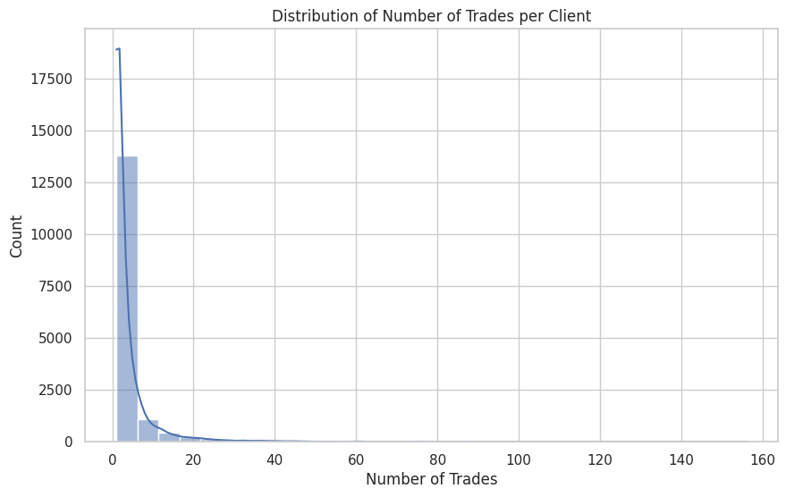

```python
# Figure size
plt.figure(figsize = (10,6))

# Create a histogram of the 'num_trades' data
sns.histplot(data=num_trades, bins=30, kde=True)

# Set plot title and axis labels
plt.title('Distribution of Number of Trades per Client')
plt.xlabel('Number of Trades')
plt.ylabel('Count')

# Show the plot
plt.show()
```

Since there is a huge tail, here is the same graph but with log scale (look at the y axis) for better visualization

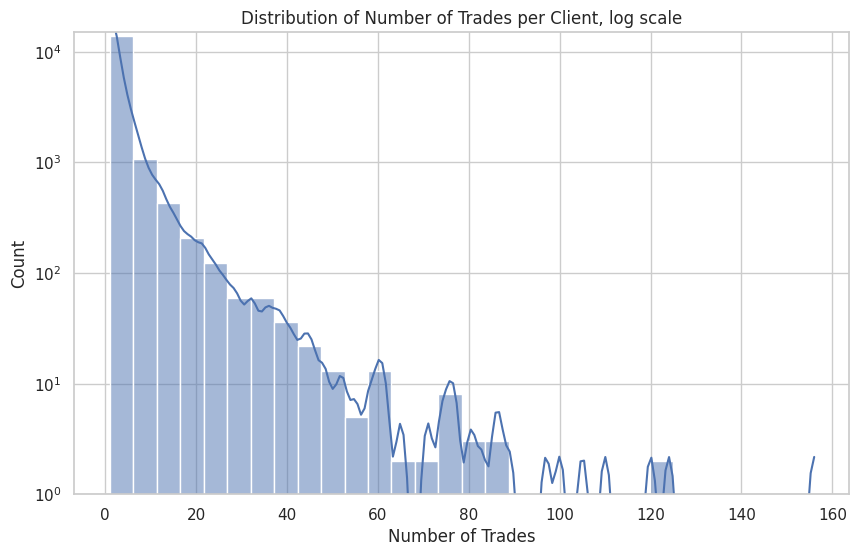

```python
import seaborn as sns
import matplotlib.pyplot as plt
# Figure size
plt.figure(figsize = (10,6))

# Create a histogram of the 'num_trades' data
sns.histplot(data=num_trades, bins=30, kde=True)

# Set plot title and axis labels
plt.title('Distribution of Number of Trades per Client, log scale')
plt.xlabel('Number of Trades',fontsize = 12)
plt.ylabel('Count',fontsize = 12)

# Use a logarithmic scale for the y-axis
plt.yscale('log')
plt.ylim(1,15000)

# Show the plot
plt.show()
```

In Log Scale, the changes are much more smooth to draw conclusions about the distribution of the data.

## Clients type summary

In this section, I will conduct a proportion analysis by computing the contribution of each client type to some columns in 'df_trades' as a percentage of the total data.

- Add 'type' to df_trades

```python
# Merge the 'result' dataframe with 'df_trades'
merged_df = pd.merge(df_trades, result[['login', 'type']], on='login', how='left')

# Remove rows with NA values
merged_df = merged_df.dropna()

# Print the merged and cleaned dataframe
merged_df.head()
```

|  | deal | login | dealer | time_deal | order | action | entry | digits | digits_currency | contract_size | ... | year_month | volume_usd | symbol_path | profit_usd | storage_usd | commission_usd | price_usd | cfd_platform | day_of_week | type |
| --- | --- | --- | --- | --- | --- | --- | --- | --- | --- | --- | --- | --- | --- | --- | --- | --- | --- | --- | --- | --- | --- |
| 416 | 937016996 | 2122528 | 1 | 2023-01-06 15:39:47.046000+00:00 | 929650601 | 0 | 1 | 5 | 2 | 100000.0 | ... | 2023-01-01T00:00:00Z | 53021.500000 | Forex Major\\EURUSD | -88.50 | 0.0 | 0.0 | 1.060430 | MT5 | 4 | mid |
| 609 | 938534865 | 2122417 | 1 | 2023-01-12 09:24:42.913000+00:00 | 931038376 | 1 | 1 | 5 | 2 | 100000.0 | ... | 2023-01-01T00:00:00Z | 3000.000000 | Forex Major\\USDCHF | -2.19 | 0.0 | 0.0 | 0.998917 | MT5 | 3 | mid |
| 1794 | 938195558 | 2118235 | 1 | 2023-01-11 06:57:23.742000+00:00 | 930720754 | 0 | 1 | 5 | 2 | 100000.0 | ... | 2023-01-01T00:00:00Z | 21433.400000 | Forex Minor\\AUDCAD | 23.80 | 0.0 | 0.0 | 0.691242 | MT5 | 2 | mid |
| 1814 | 942029789 | 2124327 | 1 | 2023-01-24 22:06:12.832000+00:00 | 934437995 | 0 | 1 | 5 | 2 | 100000.0 | ... | 2023-01-01T00:00:00Z | 3266.520000 | Forex Major\\EURCHF | -2.73 | 0.0 | 0.0 | 1.088958 | MT5 | 1 | mid |
| 3148 | 940831881 | 2123538 | 1 | 2023-01-20 08:23:50.904000+00:00 | 933305497 | 1 | 1 | 2 | 2 | 1.0 | ... | 2023-01-01T00:00:00Z | 4797.785376 | Stock Indices\\UK_100 | -18.51 | 0.0 | 0.0 | 9609.238771 | MT5 | 4 | mid |

5 rows × 49 columns

- Remove NAN

```python
merged_df = merged_df.dropna()
```

- Summary

```python
# Create a list of columns to summarize
cols_to_summarize = ['type','dealer', 'order', 'action', 'entry', 'digits', 'digits_currency', 'contract_size',
                     'price', 'volume', 'volume_ext', 'volume_closed', 'volume_closed_ext', 'profit',
                     'storage', 'rate_profit', 'rate_margin', 'profit_raw', 'price_position',
                     'tick_value', 'tick_size', 'reason', 'price_gateway', 'volume_usd',
                     'profit_usd', 'storage_usd', 'price_usd']
```

- Create the viz

```python
merged_df = merged_df[cols_to_summarize]
```

```python
client_types = ['small', 'mid', 'top']

# Calculate the summary statistics for each client type and column
summary = merged_df.groupby('type')[cols_to_summarize].mean()

# Calculate the proportion of each column for each client type
proportions = summary.div(summary.sum(axis=0), axis=1)
```

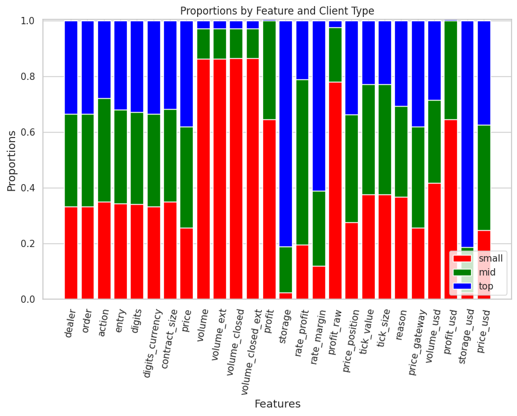

```python
# define colors for each client type
colors = {'small': 'red', 'mid': 'green', 'top': 'blue'}

# create a stacked vertical bar chart
fig, ax = plt.subplots(figsize=(10,6))
bottom = np.zeros(len(proportions.columns))
for index in proportions.index:
    values = proportions.loc[index].values
    ax.bar(proportions.columns, values, bottom=bottom, color=colors[index])
    bottom += values

# add labels and legend
ax.set_xlabel('Features',fontsize = 13)
ax.set_ylabel('Proportions',fontsize = 13)
ax.set_title('Proportions by Feature and Client Type')
ax.legend(proportions.index, loc='lower right')

# set x-axis tick label rotation
plt.xticks(rotation=80)

plt.show()
```

By examining the graph, we can readily observe how the proportions differ depending on the features. For instance, small clients primarily dominate features that are related to "volume," whereas "storage_usd" comprises mostly top clients.